# Tutorial 5 - Seaborn & Clustering

## Outline

- Introduction and installation
- Data visualization with `catplot`, `relplot` and `pairplot`
- Correlation matrix
- Clustering
- Quick Markdown & LaTeX syntax

## Seaborn

- [Documentation](https://seaborn.pydata.org/index.html)
- Installation: `pip install seaborn` or `conda install seaborn -c conda-forge`

Seaborn is a Python data visualization library based on matplotlib. It provides a high-level interface for drawing attractive and informative statistical graphics. Seaborn also provides better integration with Pandas data structures.

[figure not shown]

### Bar Plot

```python
import pandas as pd
import seaborn as sns
```

```python
df = pd.read_csv("Datasets/compounds.csv")
df.head()
```

|  | A | B | C | D | type | Start assignment |
| --- | --- | --- | --- | --- | --- | --- |
| 0 | 6.4 | 2.9 | 4.3 | 1.3 | amide | 1 |
| 1 | 5.7 | 4.4 | 1.5 | 0.4 | phenol | 2 |
| 2 | 6.7 | 3.0 | 5.2 | 2.3 | ether | 0 |
| 3 | 5.8 | 2.8 | 5.1 | 2.4 | ether | 1 |
| 4 | 6.4 | 3.2 | 5.3 | 2.3 | ether | 0 |

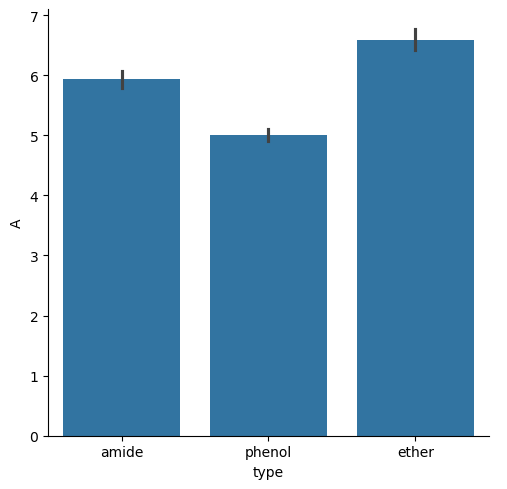

```python
sns.catplot(data=df, x='type', y='A', kind='bar')
```

### Violin plot

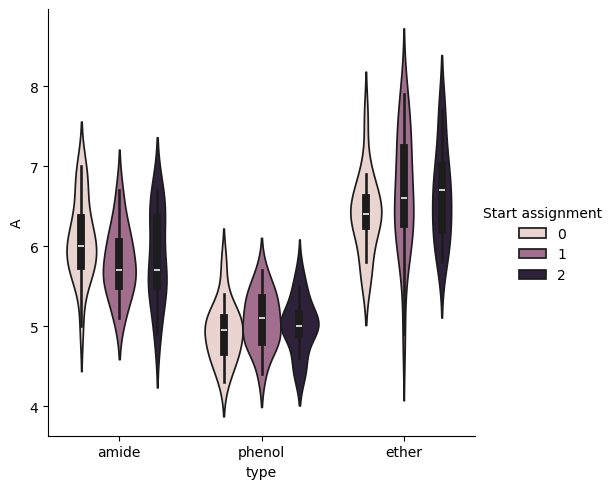

```python
sns.catplot(data=df, kind='violin', x='type', y='A', hue='Start assignment')
```

### Scatter plot

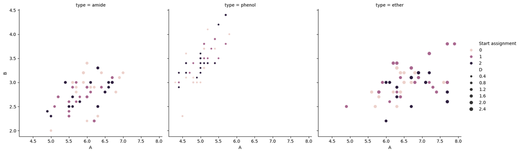

```python
sns.relplot(data=df, x='A', y='B', col='type', hue='Start assignment', size='D')
```

### Pair Plot

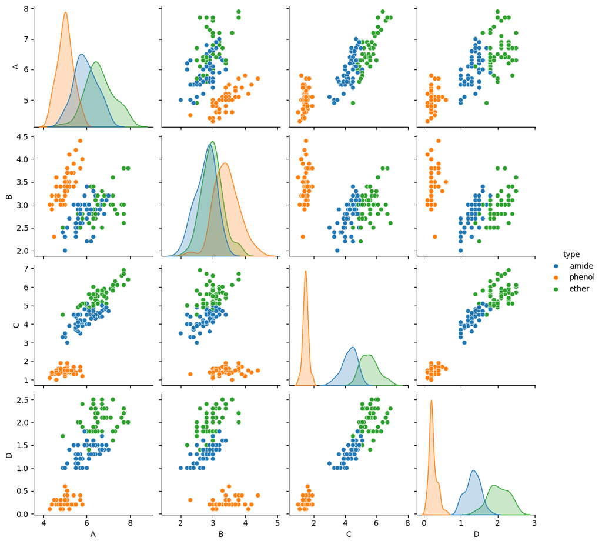

```python
newdf = df.drop(['Start assignment'], axis=1)
sns.pairplot(data=newdf, hue='type')
```

## Correlation matrix

The **correlation coefficient** between two random variables $\mathrm{X}$ and $\mathrm{Y}$ are defined as:

$$\frac{\mathrm{Cov}(\mathrm{X,Y})}{\sqrt{\mathrm{Var}(\mathrm{X})\mathrm{Var}(\mathrm{Y})}}=\frac{\sum_{i}(X_i-\bar{X})(Y_i-\bar{Y})}{\sqrt{[\sum_i (X_i-\bar{X})^2][\sum_i (Y_i-\bar{Y})^2]}}$$

The correlation coefficient should be in the range of $[-1, 1]$. When $X=Y$, the correlation coefficient will be $1$, and when $X=-Y$ the correlation coefficient will be $-1$.

```python
import numpy as np


X = np.random.random(1000)
Y = np.random.random(1000)
Y = 2 * X + np.random.random(1000) * 0.1

def corrcoef(X, Y):
    X_shift = X - np.mean(X)
    Y_shift = Y - np.mean(Y)
    return np.sum(X_shift * Y_shift) / np.sqrt(np.sum(X_shift ** 2) * np.sum(Y_shift ** 2))

corrcoef(X, Y)
```

```
0.9986565748511288
```

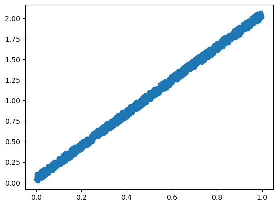

```python
import matplotlib.pyplot as plt

plt.scatter(X, Y)
```

```python
wines = pd.read_csv("Datasets/wines.csv").iloc[:, :-2]
features = wines.values
features.shape
```

[output not shown]

```python
# use numpy to calculate corr coef
corrmat = np.corrcoef(features.T)
corrmat
```

```
array([[ 1.        ,  0.09439694,  0.2115446 , -0.31023514,  0.27079823,
         0.28910112,  0.23681493, -0.15592947,  0.13669791,  0.5463642 ,
        -0.0717472 ,  0.07234319,  0.64372004],
       [ 0.09439694,  1.        ,  0.16404547,  0.2885004 , -0.0545751 ,
        -0.335167  , -0.41100659,  0.29297713, -0.22074619,  0.24898534,
        -0.56129569, -0.36871043, -0.19201056],
       [ 0.2115446 ,  0.16404547,  1.        ,  0.44336719,  0.28658669,
         0.12897954,  0.11507728,  0.18623045,  0.00965194,  0.25888726,
        -0.07466689,  0.00391123,  0.22362626],
       [-0.31023514,  0.2885004 ,  0.44336719,  1.        , -0.08333309,
        -0.32111332, -0.35136986,  0.36192172, -0.19732684,  0.01873198,
        -0.27395522, -0.27676855, -0.44059693],
       [ 0.27079823, -0.0545751 ,  0.28658669, -0.08333309,  1.        ,
         0.21440123,  0.19578377, -0.25629405,  0.23644061,  0.19995001,
         0.0553982 ,  0.06600394,  0.39335085],
       [ 0.28910112, -0.335167  ,  0.12897954, -0.32111332,  0.21440123,
         1.        ,  0.8645635 , -0.4499353 ,  0.61241308, -0.05513642,
         0.43368134,  0.69994936,  0.49811488],
       [ 0.23681493, -0.41100659,  0.11507728, -0.35136986,  0.19578377,
         0.8645635 ,  1.        , -0.53789961,  0.65269177, -0.1723794 ,
         0.54347857,  0.7871939 ,  0.49419313],
       [-0.15592947,  0.29297713,  0.18623045,  0.36192172, -0.25629405,
        -0.4499353 , -0.53789961,  1.        , -0.3658451 ,  0.13905701,
        -0.26263963, -0.5032696 , -0.31138519],
       [ 0.13669791, -0.22074619,  0.00965194, -0.19732684,  0.23644061,
         0.61241308,  0.65269177, -0.3658451 ,  1.        , -0.02524993,
         0.29554425,  0.5190671 ,  0.3304167 ],
       [ 0.5463642 ,  0.24898534,  0.25888726,  0.01873198,  0.19995001,
        -0.05513642, -0.1723794 ,  0.13905701, -0.02524993,  1.        ,
        -0.52181319, -0.42881494,  0.31610011],
       [-0.0717472 , -0.56129569, -0.07466689, -0.27395522,  0.0553982 ,
         0.43368134,  0.54347857, -0.26263963,  0.29554425, -0.52181319,
         1.        ,  0.56546829,  0.23618345],
       [ 0.07234319, -0.36871043,  0.00391123, -0.27676855,  0.06600394,
         0.69994936,  0.7871939 , -0.5032696 ,  0.5190671 , -0.42881494,
         0.56546829,  1.        ,  0.31276108],
       [ 0.64372004, -0.19201056,  0.22362626, -0.44059693,  0.39335085,
         0.49811488,  0.49419313, -0.31138519,  0.3304167 ,  0.31610011,
         0.23618345,  0.31276108,  1.        ]])
```

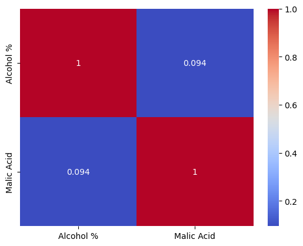

```python
# seaborn vis
sns.heatmap(corrmat[:2, :2], cmap='coolwarm', xticklabels=wines.columns[:2], yticklabels=wines.columns[:2], annot=True)
```

## Clustering

Clustering is a machine learning technique that involves grouping a set of objects in such a way that objects in the same group (called a cluster) are more similar to each other than to those in other groups. It's widely used for exploratory data analysis to find natural groupings, patterns, or structures within data without prior knowledge of group definitions.

[figure not shown]

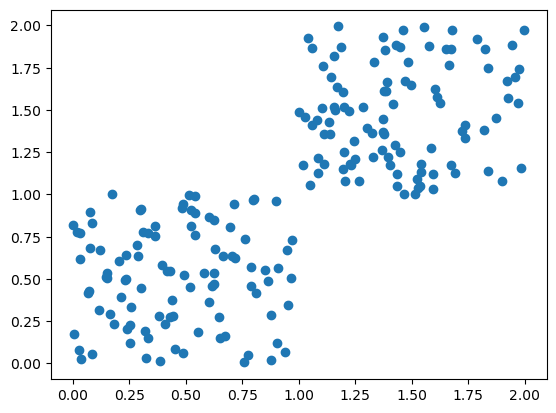

```python
from sklearn.preprocessing import StandardScaler
import matplotlib.pyplot as plt


def generate_data():
    return np.vstack([
        np.random.random((100, 2)),
        np.random.random((100, 2)) + 1
    ])

data = generate_data()
plt.scatter(data[:, 0], data[:, 1])
```

```python
# cluster with K-Means
from sklearn.cluster import KMeans

model = KMeans(2)
model.fit(data)
```

```
KMeans(n_clusters=2)
```

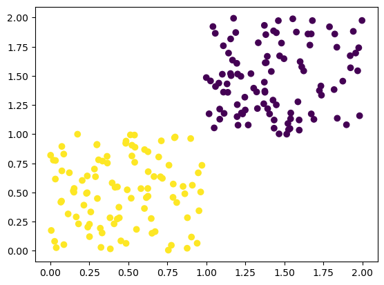

```python
plt.scatter(data[:, 0], data[:, 1], c=model.labels_)
```

## Quick Markdown & LaTeX Syntax

# Header 1

## Header 2

### Header 3

List:

- Foo
- Bar

**Bold**

*Italic*

Inline Math: $A, B, C, D, \alpha, \beta, \gamma, \lambda, \delta$

Displaymode Math:

$$ \frac{\partial f}{\partial X} $$$$ \mathrm{A}, \mathbf{X} $$

[Hyperlink](http://www.google.com)

List:

- Foo
- Bar

**bold** *italic*

[Hyperlink](https://google.com)